# Causal ML: Double ML as generic recipe

Application notebook

Michael Knaus

02/23

Goals:

- Hand-code partially linear (IV) and AIPW for ATE/ATT/LATE with the generic Double ML recipe
- Test $H_0: ATT = ATE$, $H_0: LATE = ATE$ and $H_0: (ATT - ATE) / ATE \times 100 = 0$ using the chain rule of influence functions

# 401(k) dataset again

We again use the data of the `hdm` package. The data was used in [Chernozhukov and Hansen (2004)](https://direct.mit.edu/rest/article/86/3/735/57586/The-Effects-of-401-K-Participation-on-the-Wealth). Their paper investigates the effect of participation in the employer-sponsored 401(k) retirement savings plan (*p401*) on net assets (*net_tfa*). Since then, the data was used to showcase many new methods. It is not the most comprehensive dataset with basically ten covariates/regressors/predictors:

- *age*: age
- *db*: defined benefit pension
- *educ*: education (in years)
- *fsize*: family size
- *hown*: home owner
- *inc*: income (in US $)
- *male*: male
- *marr*: married
- *pira*: participation in individual retirement account (IRA)
- *twoearn*: two earners

However, it is publicly available and the few controls ensure that the programs run not as long as with datasets that you hope to have for your applications.

```r
library(hdm)
library(causalDML)
library(grf)
library(tidyverse)

set.seed(1234) # for replicability

# Get data
data(pension)
# Outcome
Y = pension$net_tfa
# Treatment
W = pension$p401
# Treatment
Z = pension$e401
# Create main effects matrix
X = model.matrix(~ 0 + age + db + educ + fsize + hown + inc + male + marr + pira + twoearn, data = pension)
```

We want to estimate the effect of 401(k) participation on net assets. We leverage two identification strategies:

- Based on unconfoundedness as before
- using eligibility for 401(k) as instrument for actual participation

and use estimators that assume constant effects (partially linear) and allow for heterogeneous effects (ATE, ATT, LATE).

In total we want to implement five estimators:

# Nuisance parameters

We need a bunch of nuisance parameters to do so. The ones we know already are

- $e(X)=E[W|X]$ coded as `exhat`
- $m(X)=E[Y|X]$ coded as `mxhat`
- $m(0,X)=E[Y|W=0,X]$ coded as `mwhat0`
- $m(1,X)=E[Y|W=1,X]$ coded as `mwhat1`

Additionally, we need

- $h(X)=E[Z|X]$ to be coded as `hhat`
- $m_z(0,X)=E[Y|Z=0,X]$ to be coded as `mzhat0`
- $m_z(1,X)=E[Y|Z=1,X]$ to be coded as `mzhat1`
- $e(0,X)=E[W|Z=0,X]$ to be coded as `ezhat0`
- $e(1,X)=E[W|Z=1,X]$ to be coded as `ezhat1`

```r
n = length(Y)
nfolds = 5
fold = sample(1:nfolds,n,replace=T)

exhat = mxhat = mwhat0 = mwhat1 = hhat = mzhat0 = mzhat1 = ezhat0 = ezhat1 = rep(NA,n)

for (i in 1:nfolds){
  rfe = regression_forest(X[fold != i,],W[fold != i])
  exhat[fold == i] = predict(rfe, X[fold == i,])$predictions

  rfm = regression_forest(X[fold != i,],Y[fold != i])
  mxhat[fold == i] = predict(rfm, X[fold == i,])$predictions

  rfm0 = regression_forest(X[fold != i & W==0,],Y[fold != i & W==0])
  mwhat0[fold == i] = predict(rfm0, X[fold == i,])$predictions

  rfm1 = regression_forest(X[fold != i & W==1,],Y[fold != i & W==1])
  mwhat1[fold == i] = predict(rfm1, X[fold == i,])$predictions

  rfh = regression_forest(X[fold != i,],Z[fold != i])
  hhat[fold == i] = predict(rfh, X[fold == i,])$predictions

  rfmz0 = regression_forest(X[fold != i & Z==0,],Y[fold != i & Z==0])
  mzhat0[fold == i] = predict(rfmz0, X[fold == i,])$predictions

  rfmz1 = regression_forest(X[fold != i & Z==1,],Y[fold != i & Z==1])
  mzhat1[fold == i] = predict(rfmz1, X[fold == i,])$predictions

  rfez0 = regression_forest(X[fold != i & Z==0,],W[fold != i & Z==0])
  ezhat0[fold == i] = predict(rfez0, X[fold == i,])$predictions

  rfez1 = regression_forest(X[fold != i & Z==1,],W[fold != i & Z==1])
  ezhat1[fold == i] = predict(rfez1, X[fold == i,])$predictions
}
```

and finally the easy $e=E[W]$ coded as `ehat`

```r
ehat = mean(W)
```

# $\psi_a$ and $\psi_b$ of each scores

Now we code up the two components of the score, that will help us later to get the point estimate and the standard error using the same function.

## PL

The empirical version of the score looks like this:
$$\psi^{PL}(O;\hat{\tau},\hat{\eta}) = \hat{\tau}
\underbrace{(-1)(W - \hat{e}(X))^2}_{\psi_a^{PL}} + \underbrace{ (Y -
\hat{m}(X)) (W - \hat{e}(X))}_{\psi_b^{PL}}$$
To follow the recipe, we need two components:

1. $\psi_a^{PL}$ to be coded as `pa_pl`
2. $\psi_b^{PL}$ to be coded as `pb_pl`

```r
pa_pl = -(W - exhat)^2
pb_pl = (Y - mxhat) * (W - exhat)
-sum(pb_pl) / sum(pa_pl)
```

```
[1] 13972.06
```

## ATE

1. $\psi_a^{ATE}$ to be coded as `pa_ate`
2. $\psi_b^{ATE}$ to be coded as `pb_ate`

```r
pa_ate = rep(-1,length(Y))
pb_ate = mwhat1 - mwhat0 + W * (Y - mwhat1) / ehat - (1 - W) * (Y - mwhat0) / (1-ehat)
-sum(pb_ate) / sum(pa_ate)
```

```
[1] 12356.5
```

## ATT

The empirical version of the score looks like this:
$$\psi^{ATT}(O;\hat{\tau}_{ATT},\hat{\eta})=
\hat{\tau}_{ATT} \underbrace{(-1)\frac{W}{\hat{e}}}_{\psi_a^{ATT}} +
\underbrace{\dfrac{W}{\hat{e}} (Y - \hat{m}(0,X)) - \dfrac{ (1-W)
\hat{e}(X) }{\hat{e} (1-\hat{e}(X))} (Y - \hat{m}(0,X))
}_{\psi_b^{ATT}}$$
To follow the recipe, we need two components:

1. $\psi_a^{ATT}$ to be coded as `pa_att`
2. $\psi_b^{ATT}$ to be coded as `pb_att`

```r
pa_att = -W / ehat
pb_att = W * (Y - mwhat0) / ehat - ( (1 - W) * exhat ) * (Y - mwhat0) / (ehat * (1 - ehat))
-sum(pb_att) / sum(pa_att)
```

```
[1] 14796
```

## PL-IV

The empirical version of the score looks like this:
$$\psi^{IV}(O;\hat{\tau}_{IV},\hat{\eta})=
\hat{\tau}_{IV} \underbrace{(-1) (W - \hat{e}(X)) (Z -
\hat{h}(X))}_{\psi_a^{IV}} + \underbrace{(Y - \hat{m}(X)) (Z -
\hat{h}(X))}_{\psi_b^{IV}}$$
To follow the recipe, we need two components:

1. $\psi_a^{IV}$ to be coded as `pa_iv`
2. $\psi_b^{IV}$ to be coded as `pb_iv`

```r
pa_iv = -(W - exhat) * (Z - hhat)
pb_iv = (Y - mxhat) * (Z - hhat)
-sum(pb_iv) / sum(pa_iv)
```

```
[1] 12892.28
```

## LATE

The empirical version of the score looks like this:
$$\begin{align}
\psi^{LATE}(O;\hat{\tau}_{LATE},\hat{\eta}) & = \hat{\tau}_{LATE}
\underbrace{ (-1) \Bigg[ \hat{e}(1,X) - \hat{e}(0,X) + \dfrac{Z (W -
\hat{e}(1,X))}{\hat{h}(X)} - \dfrac{(1-Z) (W -
\hat{h}(0,X))}{1-\hat{h}(X)} \Bigg] }_{\psi_a^{LATE}} \\
& \quad + \underbrace{\hat{m}_z(1,X) - \hat{m}_z(0,X) + \dfrac{Z (Y
- \hat{m}_z(1,X))}{\hat{h}(X)} - \dfrac{(1-Z) (Y -
\hat{m}_z(0,X))}{1-\hat{h}(X)}}_{\psi_b^{LATE}}
\end{align}$$
To follow the recipe, we need two components:

1. $\psi_a^{LATE}$ to be coded as `pa_late`
2. $\psi_b^{LATE}$ to be coded as `pb_late`

```r
pa_late = -( ezhat1 - ezhat0 + Z * (W - ezhat1) / hhat - (1 - Z) * (W - ezhat0) / (1-hhat) )
pb_late = mzhat1 - mzhat0 + Z * (Y - mzhat1) / hhat - (1 - Z) * (Y - mzhat0) / (1-hhat)
-sum(pb_late) / sum(pa_late)
```

```
[1] 11194.11
```

# A generic function for Double ML with linear score

Now we write a function that takes any $\psi_a$ and $\psi_b$ as inputs and outputs

- point estimate
- standard error
- t-value
- p-value

```r
DML_inference = function(psi_a,psi_b) {
  N = length(psi_a)
  theta = -sum(psi_b) / sum(psi_a)
  psi = theta * psi_a + psi_b
  Psi = - psi / mean(psi_a)
  sigma2 = var(Psi)
  # sigma2 = mean(psi^2) / mean(psi_a)^2
  se = sqrt(sigma2 / N)
  t = theta / se
  p = 2 * pt(abs(t),N,lower = FALSE)
  result = c(theta,se,t,p)
  return(result)
}
```

# Results

```r
results = matrix(NA,5,4)
rownames(results) = c("PL","ATE","ATT","PL-IV","LATE")
colnames(results) = c("Effect","S.E.","t","p")
results[1,] = DML_inference(pa_pl,pb_pl)
results[2,] = DML_inference(pa_ate,pb_ate)
results[3,] = DML_inference(pa_att,pb_att)
results[4,] = DML_inference(pa_iv,pb_iv)
results[5,] = DML_inference(pa_late,pb_late)
printCoefmat(results,has.Pvalue = TRUE)
```

```
       Effect    S.E.      t         p
PL    13972.1  1538.8 9.0800 < 2.2e-16 ***
ATE   12356.5  1469.2 8.4102 < 2.2e-16 ***
ATT   14796.0  1647.5 8.9808 < 2.2e-16 ***
PL-IV 12892.3  1923.4 6.7029 2.154e-11 ***
LATE  11194.1  1699.1 6.5881 4.681e-11 ***
---
Signif. codes:  0 ‘***’ 0.001 ‘**’ 0.01 ‘*’ 0.05 ‘.’ 0.1 ‘ ’ 1
```

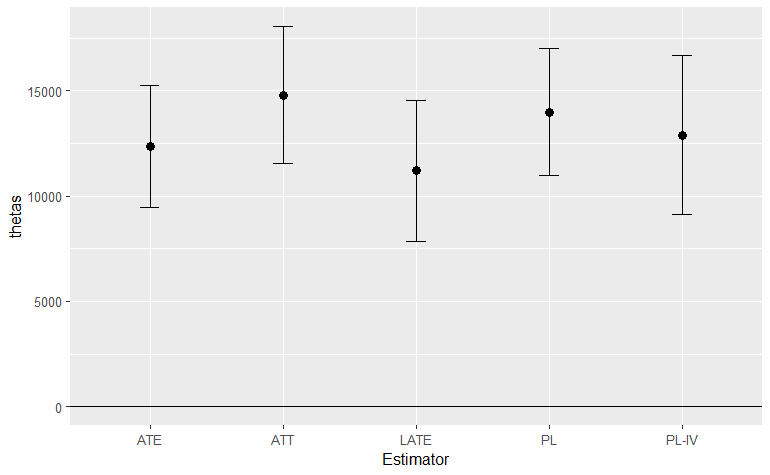

```r
data.frame(thetas = results[,1],ses = results[,2],
                Estimator = rownames(results),
                cil = results[,1] - 1.96*results[,2],
                ciu = results[,1] + 1.96*results[,2])  %>%
  ggplot(aes(x=Estimator,y=thetas,ymin=cil,ymax=ciu)) + geom_point(size=2.5) + geom_errorbar(width=0.15)  +
  geom_hline(yintercept=0)
```

# ATT vs. ATE

Assume that we want to test whether $ATT=ATE$.

For this purpose, we create the new parameter $\Delta_{ATT} = \tau_{ATT} - \tau_{ATE}$ and want to test $H_0:\Delta(\tau_{ATT},\tau_{ATE}) = 0$

The influence function of this new parameter can derived like this:
$$\begin{align*}
\Psi_\Delta & = \overbrace{\frac{\delta \Delta}{\delta
\tau_{ATT}}}^{=1} \Psi_{\tau_{ATT}} + \overbrace{\frac{\delta
\Delta}{\delta \tau_{ATE}}}^{=-1} \Psi_{\tau_{ATE}} \\
& = \Psi_{\tau_{ATT}} - \Psi_{\tau_{ATE}}
\end{align*}$$

Define for convenience and later use a `Psi_maker()` function that creates the influence function for generic $\psi_a$ and $\psi_b$:

```r
Psi_maker = function(psi_a,psi_b) {
  theta = -sum(psi_b) / sum(psi_a)
  psi = theta * psi_a + psi_b
  Psi = - psi / mean(psi_a)
  return(Psi)
}
```

Now this can be used to test $H_0:\Delta(\tau_{ATT},\tau_{ATE}) = 0$:

```r
# Calculate parameters
att = - sum(pb_att) / sum(pa_att)
ate = - sum(pb_ate) / sum(pa_ate)
Delta_att = att - ate
# Create influence function for new parameter
Psi_Delta_att = Psi_maker(pa_att,pb_att) - Psi_maker(pa_ate,pb_ate)
# Calculate standard errors, t and pvalues
se_Delta_att = sqrt(var(Psi_Delta_att)/length(Psi_Delta_att))
t_Delta_att = Delta_att / se_Delta_att
p_Delta_att = 2 * pt(abs(t_Delta_att),length(Psi_Delta_att),lower = FALSE)
# Print results
result = matrix(c(Delta_att,se_Delta_att,t_Delta_att,p_Delta_att),nrow = 1)
rownames(result) = c("ATT-ATE")
colnames(result) = c("Delta","S.E.","t","p")
printCoefmat(result,has.Pvalue = TRUE)
```

```
          Delta    S.E.      t         p
ATT-ATE 2439.50  516.31 4.7249 2.334e-06 ***
---
Signif. codes:  0 ‘***’ 0.001 ‘**’ 0.01 ‘*’ 0.05 ‘.’ 0.1 ‘ ’ 1
```

We observe that the different between ATT and ATE is highly significant. This may come as a surprise given that the confidence intervals overlap in the graph above. However, such eyeballing does not work for correlated estimators and the ATT and ATE estimator are clearly correlated.

# LATE vs. ATE

Similarly, we can investigate $H_0:\Delta_{LATE} = \tau_{LATE} - \tau_{ATE} = 0$. (0.5P)

The derivation works like before:

$$\begin{align}
\Psi_{\Delta_{LATE}} &= \underbrace{\frac{\partial
\Delta_{LATE}}{\partial \tau_{LATE}}}_{=1} \Psi_{LATE} +
\underbrace{\frac{\partial \Delta_{LATE}}{\partial \tau_{ATE}}}_{=-1}
\Psi_{ATE} \\
\Psi_{\Delta_{LATE}} &=\Psi_{LATE} - \Psi_{ATE}
\end{align}$$

and also the inference follows the same recipe:

```r
# CalcuLATE
late = -sum(pb_late)/sum(pa_late)
# New target parameter
Delta_late = late - ate
# Create influence function for new parameter
Psi_Delta_late = Psi_maker(pa_late,pb_late) - Psi_maker(pa_ate,pb_ate)
# Print results
se_Delta_late = sqrt(var(Psi_Delta_late)/length(Psi_Delta_late))
t_Delta_late = Delta_late/se_Delta_late
p_Delta_late = 2 * pt(abs(t_Delta_late),length(Psi_Delta_late),lower = FALSE) # get a p-value (at what level would be not reject?)

results = matrix(c(Delta_late,se_Delta_late,t_Delta_late,p_Delta_late),nrow = 1)
rownames(results) = c("LATE-ATE")
colnames(results) = c("Delta","S.E.","t","p")
printCoefmat(results,has.Pvalue = TRUE)
```

```
           Delta    S.E.      t      p
LATE-ATE -1162.4  1247.2 -0.932 0.3514
```

However, the difference between LATE and ATE is not statistically significant.

# How large is the difference between ATT and ATE in %?

Finally, let’s look at a more complicated new parameter $\Delta\% = \frac{\tau_{ATT} - \tau_{ATE}}{\tau_{ATE}}\times 100$.

Following the recipe, we derive the new influence function:

$$\begin{align}
\Psi_{\Delta\%} &= \frac{\partial \Delta\%}{\partial \tau_{ATT}}
\Psi_{ATT} + \frac{\partial \Delta\%}{\partial \tau_{ATE}} \Psi_{ATE} \\
\Psi_{\Delta\%} &=100 \cdot \frac{1}{\tau_{ATE}} \Psi_{ATT} -100
\cdot \frac{\tau_{ATT}}{\tau_{ATE}^2} \Psi_{ATE}
\end{align}$$

$\Psi_{ATT}$ and $\Psi_{ATE}$ can be obtained using `Psi_maker`. $\tau_{ATE}$ and $\tau_{ATT}$ can be replaced by their estimates:

```r
# New parameter
Delta_pc = (att-ate)/ate*100
# New IF
Psi_Delta_pc = 100 / ate * Psi_maker(pa_att, pb_att) - 100 * att / (ate^2) * Psi_maker(pa_ate, pb_ate)
# Results
se_Delta_pc = sqrt(var(Psi_Delta_pc)/length(Psi_Delta_pc))
t_Delta_pc = Delta_pc/se_Delta_pc
p_Delta_pc = 2 * pt(abs(t_Delta_pc),length(Psi_Delta_pc),lower = FALSE)
results = matrix(c(Delta_pc,se_Delta_pc,t_Delta_pc,p_Delta_pc),nrow = 1)
rownames(results) = c("Delta%")
colnames(results) = c("Delta","S.E.","t","p")
printCoefmat(results,has.Pvalue = TRUE)
```

```
         Delta    S.E.      t         p
Delta% 19.7426  4.3854 4.5019 6.812e-06 ***
---
Signif. codes:  0 ‘***’ 0.001 ‘**’ 0.01 ‘*’ 0.05 ‘.’ 0.1 ‘ ’ 1
```

Not surprisingly the percentage change is significant, like the plain level difference between ATT and ATE. However, the t-values are not identical, which illustrates that we explicitly calculate the inference for such new parameters. And influence functions provide a neat tool to do so.